# Paris AirBnB Data Analysis 2009-2016

Aminu Habib Abiola

# Introduction and Objectives

Every night, hundreds of thousands of tourists prefer to pay and stay in the property of a stranger, found online on Airbnb webstie instead of booking a traditional tourism accommodation such as a hotel. Since Airbnb 2008, proposed an online platform where people can rent mostly for tourism different type of properties: rooms, appartments, houses and sometimes more esoteric places. Over the past several years Airbnb has rapidly and massively grown to the point that today anyone can rent and find a spot virtually in any country or city of the world.

In this report we focus on Paris, capital of France, and will try to decipher some general tendencies regarding the prices proposed by Parisian hosts. This analysis will be performed in the frame of four major objectives. Firstly we will try to uncover the features that impact on the price of property with a specific focus on appartment. Secondly we will focus more on parisian hosts and try to determine how many appartments a parisian commonly propose for renting. Thirdly we will take a geographical approach in trying to assess whether locations of the properties impact on prices. Finally we study and quantify the number of visits in the capital longitudinally based on the number of AirBnB renting.

# Methods

## Software and packages

### Loading of the data set

```r
load("./AirBnB.Rdata")
ls()
```

```
## [1] "L" "R"
```

The **“AirBnB”** data set comes as two different tables named **L** and **R**.

We can see that the table L is highly complex with notably 95 variables of different types. Some work regarding cleaning will be needed as we will see later on. The second table R is less complex and contained only two variables. To make the naming more appropriate we are going to save both tables into variables airbnb_data and supplementary_data respectively.

```r
airbnb_data <- L
supplementary_data <- R
```

# Data Types manipulation

Interestingly price values are factor typed (fct). In R, a factor is a vector that can contain only predefined values, and is used to store categorical data. Additionnaly we can see that the *$* sign is visible. *price* should be a continuous variable and we might anticipate that manipulating this variable as fct type to make calculation would lead to some problems. Consequently we need to convert it into a more appropriate data type.

```r
airbnb_data$price <- substring(gsub(",", "", as.character(airbnb_data$price)),2)
```

Now have succeeded in removing the *$* from *price*.

```r
head(airbnb_data$price)
```

```
## [1] "60.00"  "200.00" "80.00"  "60.00"  "50.00"  "191.00"
```

## Manipulate vers a numeric variabble

To manipulate some variables notably numeric ones, we need to ensure that they are loaded with the appropriate data type. A good example of this is the values contained in the price column. We shall use the *as.numeric* function to convert the variables we are interested in.

```r
airbnb_data$bathrooms <- as.numeric((airbnb_data$bathrooms))
airbnb_data$bedrooms <- as.numeric((airbnb_data$bedrooms))
airbnb_data$beds <- as.numeric((airbnb_data$beds))
airbnb_data$price <- as.numeric((airbnb_data$price))
airbnb_data$guests_included <- as.numeric((airbnb_data$guests_included))
airbnb_data$minimum_nights <- as.numeric((airbnb_data$minimum_nights))
airbnb_data$maximum_nights <- as.numeric((airbnb_data$maximum_nights))
airbnb_data$availability_365 <- as.numeric((airbnb_data$availability_365))
airbnb_data$security_deposit <- as.numeric((airbnb_data$security_deposit))
airbnb_data$calculated_host_listings_count <- as.numeric((airbnb_data$calculated_host_listings_count))
airbnb_data$review_scores_rating <- as.numeric((airbnb_data$review_scores_rating))
airbnb_data$reviews_per_month <- as.numeric((airbnb_data$reviews_per_month))
airbnb_data$number_of_reviews <- as.numeric((airbnb_data$number_of_reviews))
airbnb_data$square_feet <- as.numeric((airbnb_data$square_feet))
```

### We replace the missing numbers with a mean

```r
mean((airbnb_data$price))
```

```
## [1] 96.51306
```

### We also do the process for bathrooms, bedrooms, beds, and square feet

```r
## Bathrooms
m = mean(airbnb_data$bathrooms,na.rm = TRUE)
sel = is.na(airbnb_data$bathrooms)
airbnb_data$bathrooms[sel] = m

## Bedrooms
m = mean(airbnb_data$bedrooms,na.rm = TRUE)
sel = is.na(airbnb_data$bedrooms)
airbnb_data$bedrooms[sel] = m

##Beds
m = mean(airbnb_data$beds,na.rm = TRUE)
sel = is.na(airbnb_data$beds)
airbnb_data$beds[sel] = m

##Square_feet
m = mean(airbnb_data$square_feet,na.rm = TRUE)
sel = is.na(airbnb_data$square_feet)
airbnb_data$square_feet[sel] = m
```

# Relationship between prices and appartment features

As a customer the first parameter to watch when renting a place is the price. It is quite obvious that prices will be greatly affected by the type of property and room we would like to rent. For example a shared-room in a dorm might be cheaper than a shared-room in a big villa. Similarly renting a full appartment should be more expensive than a single room. To get a more precise feeling about the data in Paris, we are first going to investigate the AirBnB data set under this angle and try to decipher the main factors that influence the prices of proposed properties. Ultimately we will identify what features impact more speciffically on appartments prices proposed in Paris by AirBnB hosts.

## The Parisian offer of AirBnB

Before analysing prices, it would be useful to reduce the size of our data. We could select relevant features and gather all of them in a new data table. When renting a place as a customer, there are some obvious aspects that we look at first: type of room or property, the number of rooms and bathrooms are the most obvious.

```r
colnames(airbnb_data)
```

```
##  [1] "id"                               "listing_url"
##  [3] "scrape_id"                        "last_scraped"
##  [5] "name"                             "summary"
##  [7] "space"                            "description"
##  [9] "experiences_offered"              "neighborhood_overview"
## [11] "notes"                            "transit"
## [13] "access"                           "interaction"
## [15] "house_rules"                      "thumbnail_url"
## [17] "medium_url"                       "picture_url"
## [19] "xl_picture_url"                   "host_id"
## [21] "host_url"                         "host_name"
## [23] "host_since"                       "host_location"
## [25] "host_about"                       "host_response_time"
## [27] "host_response_rate"               "host_acceptance_rate"
## [29] "host_is_superhost"                "host_thumbnail_url"
```

[output cut: 33 more lines]

To fulfill our objectives we selected the following variables: property_type, room_type, bathrooms, bedrooms, square_feet, neighbourhood_cleansed, id, host_id, price and save the resulting table into a new variable named features_and_price.

We shall investigate more closely the values present in the room_type and property_type columns.

```r
features_and_price %>%
  distinct(room_type)
```

```
##         room_type
## 1 Entire home/apt
## 2    Private room
## 3     Shared room
```

```r
features_and_price %>%
  distinct(property_type)
```

```
##      property_type
## 1        Apartment
## 2            House
## 3      Condominium
## 4             Loft
## 5            Other
## 6  Bed & Breakfast
## 7
## 8             Dorm
## 9        Townhouse
## 10            Boat
## 11           Villa
## 12            Tent
## 13           Cabin
## 14            Tipi
## 15       Camper/RV
## 16            Cave
## 17          Chalet
## 18       Treehouse
## 19     Earth House
## 20           Igloo
```

We can see that parisian hosts propose three types of rooms: Entire home/apt, Private room and Shared room. Property types are more diverse. We have some surprising propositions there as cabin, cave, chalet, earth house or igloo. A quick look at the count of these types also revealed that they represent very marginal proposition:

```r
features_and_price %>%
  count(property_type)
```

```
##      property_type     n
## 1                      3
## 2        Apartment 50663
## 3  Bed & Breakfast   394
## 4             Boat    29
## 5            Cabin     1
## 6        Camper/RV     4
## 7             Cave     1
## 8           Chalet     2
## 9      Condominium   266
## 10            Dorm    29
## 11     Earth House     1
## 12           House   537
## 13           Igloo     1
## 14            Loft   567
## 15           Other   122
## 16            Tent     1
## 17            Tipi     1
## 18       Townhouse    88
## 19       Treehouse     1
## 20           Villa    14
```

There is also a other tag here where all these unexpected propositions could have been piled in. Nevetheless other would be to vague to draw any conclusion from an analysis. Consequenlty we are going to keep only the following relevant and explicit property types to perform our analysis: Apartment, Bed & Breakfast, Boat, Condominium, Dorm, House, Loft, Townhouse, Villa.

Quantifying the number of rooms by subtypes revealed that the massive majority of available rooms were in the variable Entire home/apt (Figure 1B). Then comes the Private room and the Shared room. The picture is the same if we look now by property types. (Figure 1A). Indeed except for Bed & Breakfast which offers essentially private rooms or Dorm where you can mostly find shared rooms the other types of proprety majoritarely consist on renting the whole place (Figure 1A).

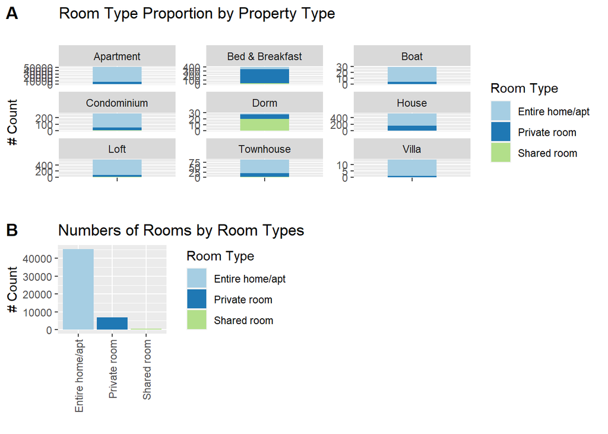

```r
room_type_count <- (ggplot(features_and_price,
                           aes(x = room_type))
                    +  geom_bar(stat = "count",
                                aes(fill = room_type))
                    +  scale_fill_brewer(palette = "Paired")
                    +  labs(title = "Numbers of Rooms by Room Types",
                            x = "",
                            y = "# Count",
                            fill = "Room Type")
                    +  theme(axis.text.x = element_text(
                            angle = 90,
                            hjust = 1,
                            vjust = 0.5)))

property_types <- (ggplot(features_and_price,
                          aes(x = "",
                              fill = room_type))
                   +  geom_bar(width = 0.5)
                   +  facet_wrap(~ property_type,
                                   scales = "free_y",
                                   ncol = 3)
                   +  scale_fill_brewer(palette = "Paired")
                   +  labs(title = "Room Type Proportion by Property Type\n",
                           x = "",
                           y = "# Count",
                           fill = "Room Type"))

ggarrange(property_types,
          nrow = 2,
          labels = "A",
          ggarrange(room_type_count,
                    ncol = 2,
                    labels = "B"))
```

*Figure 1: Room and property types.*

## Prices are significantly different among the different type of properties

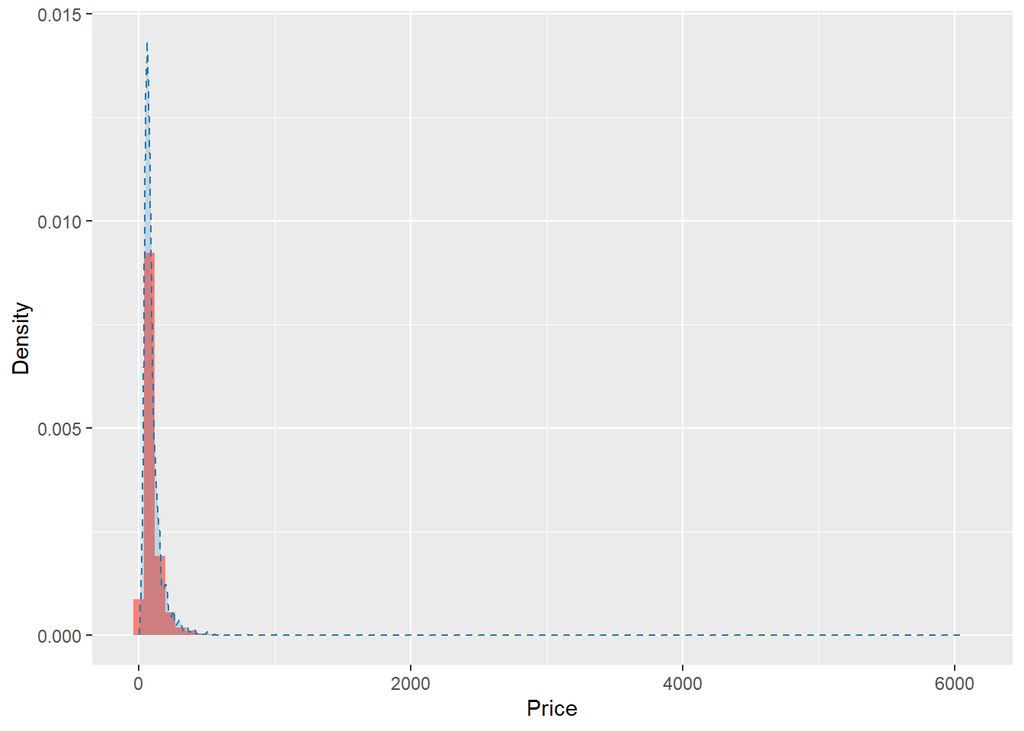

```r
(ggplot(features_and_price,
        aes(x = price))
  + geom_histogram(bins = 80,
                   aes(y = ..density..),
                   fill = "#fb8072")
  + geom_density(colour = "#1f78b4",
                 alpha = 0.2,
                 lty = 2,
                 fill = "#1f78b4")
  + labs(x = "Price",
         y = "Density"))
```

*Figure 2: Distribution of prices in Paris*

As shown in Figure 2, the distribution of the price variable is strongly skewed. More stinkingly we can see that the range of values is quite large.

```r
summary(features_and_price$price)
```

```
##    Min. 1st Qu.  Median    Mean 3rd Qu.    Max.
##    0.00   55.00   75.00   96.52  110.00 6081.00
```

A quick computation using the R summary() function – as done above – showed that the minimum price is $0 and the maximum is $6081. Although human kindness is limitless, free rent do not exist in AirBnB. Additionnaly it sounds unreasonable to spend $6081 one night for renting a property. At the time of writing, a quick request for renting in Paris using AirBnB website revealed that the range of price goes from around $10 to approximatively $1000. Consequently we will use these values as range for the variable price.

[figure not shown]

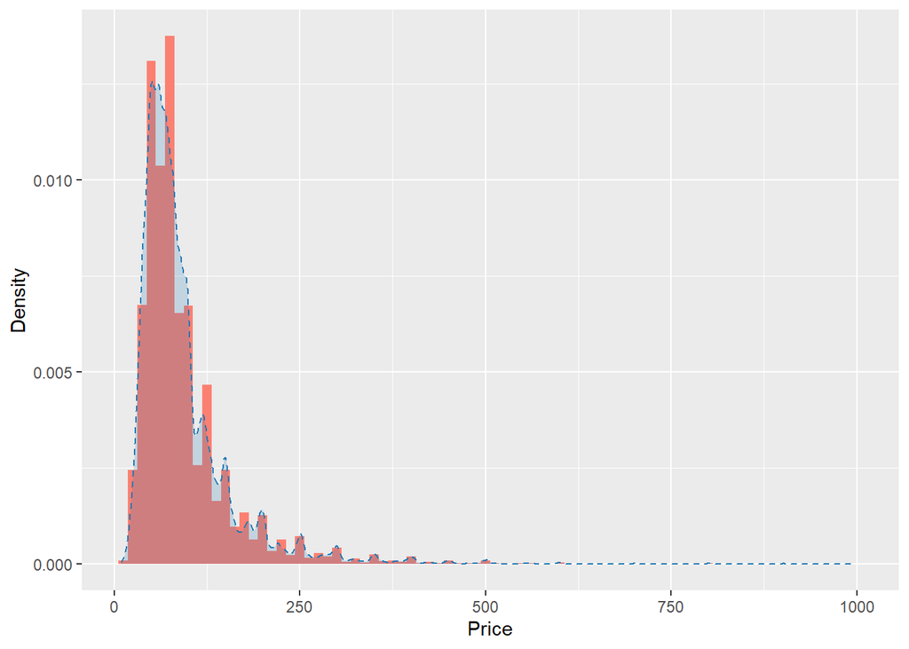

```r
features_and_price <- features_and_price %>%
filter(features_and_price$price >= 9 &
       features_and_price$price <= 1000)

(ggplot(features_and_price,
        aes(x = price))
  +  geom_histogram(bins = 80,
                    aes(y = ..density..),
                    fill = "#fb8072")
  +  geom_density(colour = "#1f78b4",
                  alpha = 0.2,
                  lty = 2,
                  fill = "#1f78b4")
  +  labs(x = "Price",
          y = "Density"))
```

*Figure 3: Updated distribution of prices in Paris.*

```r
summary(features_and_price$price)
```

```
##    Min. 1st Qu.  Median    Mean 3rd Qu.    Max.
##     9.0    55.0    75.0    95.1   110.0   997.0
```

After cleaning we can see that median of prices is still $75 with a minimum at $9 and and a maximum at $997. The distribution is not gaussian but remains less skewed (Figure 3). Next we will investigate if prices are different between property types proposed in Paris by AirBnB hosts.

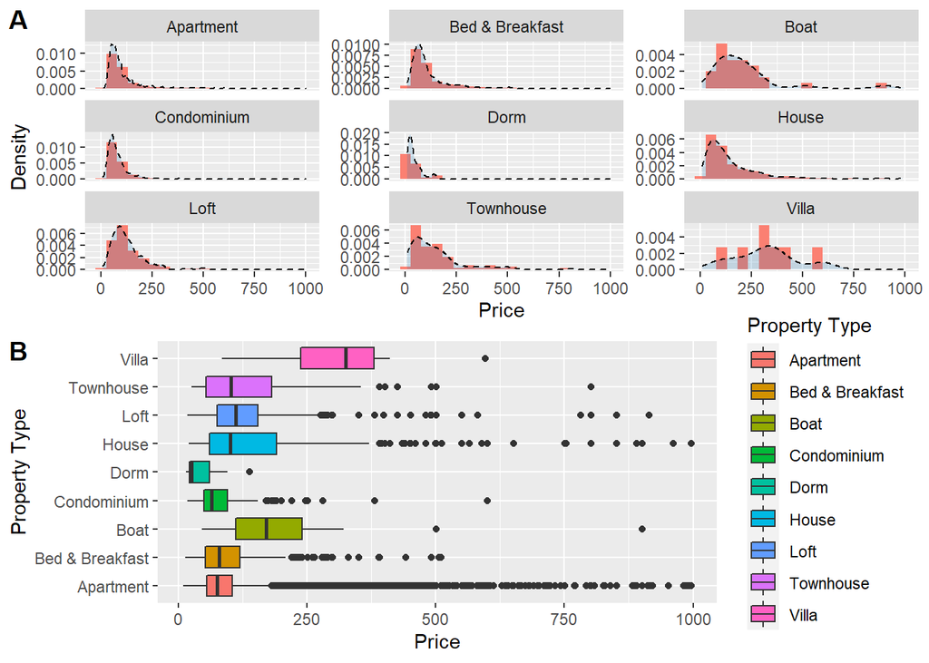

```r
price_by_property <- (ggplot(features_and_price,
                             aes(x = price))
                      +  geom_histogram(bins = 20,
                                        aes(y = ..density..),
                                        fill = "#fb8072")
                      +  geom_density(alpha = 0.2,
                                      lty = 2,
                                      fill = "#1f78b4")
                      +  facet_wrap(~ property_type,
                                    scales = "free_y")
                      +  labs(x = "Price",
                              y = "Density"))

box_price_by_property <- (ggplot(features_and_price)
                          +  geom_boxplot(aes(x = property_type,
                                              y = price,
                                              fill = property_type))
                          +  labs(x = "Property Type",
                                  y = "Price",
                                  fill = "Property Type")
                          +  coord_flip())

ggarrange(price_by_property,
          box_price_by_property,
          nrow = 2,
          labels = c("A", "B"))
```

*Figure 4: Visualization of Prices According to Property Types.*

## Number of bedrooms and the location significantly impacts on the prices of Parisian appartments avalaible in AirBnB

In our next part of our analysis we are going to focus on appartments and try to decipher which feature – among the following: bathrooms, bedrooms , accommodates and neighbourhood_cleansed – impacts on nightly prices.

```r
apt_features_and_price <- features_and_price %>%
  filter(property_type == "Apartment")
```

The variable bathroom has surprising values. Actually this comes from real estate listings where there is definition for full, half or 3/4 bathroom. I am not going to comment this, which I think is a pure anglon-saxon way of seeing and optimizing things. Here we are going to consider that 0.5 is not a bathroom. A bathroom is a room with a sink and a bathtop minimum. So I make the arbitrary choice here to round down the values assigned to the bathroom variable.

As shown in Figure 5A & 5C the prices and number of bathrooms concomitantly increase up to 3 bathrooms. At 4 and 5 bathrooms prices start to have a very inconsistent distribution. Above it, values are even more unexpected. Indeed for 6, 7 and 8 bathrooms prices are very low. The most plausible explanation to this could be that renting offers with number of bathrooms superior to 5 would in reality consist of private or shared rooms in big appartments. Let’s check this.

```r
apt_features_and_price %>%
  filter(bathrooms > 5) %>%
  count(room_type)
```

```
##         room_type  n
## 1 Entire home/apt 27
## 2    Private room 15
```

As we can see here the majority of renting offers in appartments with a number of bathrooms superior to 5 do not correspond to shared or private rooms. Another possibility could be that some offers while proposing access to an entire appartment will in reality propose you to sleep on a couch ! This is actually how AirBnB started in San-Fransisco in 2008. So you would be in an entire house with several bathrooms but will sleep on a sofa ! Figure 5E is an attempt to investigate this point. In this figure, columns correspond to the number of available bedrooms and rows correspond to the number of bathrooms. For readability we limit both numbers to 6. First we can see that we have offers with no bedrooms ! This suggest that the rentee should sleep on a sofa, a couch or a matrice. For 5 bathrooms we can see that the data is split in two with some offers proposing several bedrooms and others none (Figure 5A & E). Altogether data depicted in Figure 5A & E suggest that the number of bathrooms is not the most reliable factor to rely on to anticipate the price of an appartment on AirBnB. Number of bedrooms however seems to be more accurate in this regard. (Figure 5B & 5D). We can clearly see a concomitant increase of prices in function of the number of bedrooms which strongly suggests that the bedrooms variable is reliable to anticipate prices of parisian appartments available on AirBnB.

# Number of apartments per host

```r
count_by_host_1 <- apt_features_and_price %>%
  group_by(host_id) %>%
  summarise(number_apt_by_host = n()) %>%
  ungroup() %>%
  mutate(groups = case_when(
    number_apt_by_host == 1 ~ "001",
    between(number_apt_by_host, 2, 5) ~ "002-005",
    number_apt_by_host > 5 ~ "006-152"
    )
  )

count_by_host_2 <- count_by_host_1 %>%
  group_by(groups) %>%
  summarise(counting = n())
```

[figure not shown]

```r
apt_features_and_price["bathrooms"] <- apt_features_and_price["bathrooms"] %>%
  map(., floor)

bath_distr <- (ggplot(apt_features_and_price,
                      aes(x = price))
               +  geom_histogram(bins = 15,
                                 aes(y = ..density..),
                                 fill = "#fb8072")
               +  geom_density(lty = 2, color = "#1f78b4")
               +  labs(title = "Distribution of prices vs Bathroom numbers",
                       x = "Price",
                       y = "Density")
               +  theme(axis.text.x = element_text(angle = 90,
                                                   hjust = 1,
                                                  vjust = 0.5),
                        axis.text.y = element_text(size = 7))
               +  facet_wrap(~ factor(bathrooms),
                             scales = "free_y"))

beds_distr <- (ggplot(apt_features_and_price,
                      aes(x = price))
               +  geom_histogram(bins = 15,
                                 aes(y = ..density..),
                                 fill = "#fb8072")
               +  geom_density(lty = 2,
                               color = "#1f78b4")
               +  labs(title = "Distribution of prices vs Bedrooms numbers",
                       x = "Price",
                       y = "")
               +  theme(axis.text.x = element_text(angle = 90,
                                                   hjust = 1,
                                                   vjust = 0.5),
                        axis.text.y = element_text(size = 7))
               +  facet_wrap(~ factor(bedrooms),
                             scales = "free_y"))

beds_box <- (ggplot(apt_features_and_price)
            +  geom_boxplot(aes(x = factor(bedrooms),
                            y = price,
                            fill = factor(bedrooms)))
            +  labs(x = "# of Bedrooms",
                    y = "Price",
                    fill = "# of Bedrooms")
            +  coord_flip())


## Select for bathrooom <= 6 for graphical purpose
apt_features_and_price_bath <- apt_features_and_price %>%
  filter(bathrooms <= 6)

bath_box <- (ggplot(apt_features_and_price_bath)
             +  geom_boxplot(aes(x = factor(bathrooms),
                             y = price,
                             fill = factor(bathrooms)))
             +  labs(x = "# of Bathrooms",
                     y = "Price",
                     fill = "# of Bathrooms")
             +  coord_flip())

bivariate_plot <- (ggplot(apt_features_and_price_bath)
                   +  geom_boxplot(aes(x = "",
                                       y = price,
                                       fill = factor(bedrooms)))
                   +  labs(x = "",
                           y = "Price",
                           fill = "# Bedrooms")
                   +  facet_grid(rows = vars(bathrooms),
                                 cols = vars(bedrooms)))

num_apt_by_host_id <- (ggplot(count_by_host_2, aes(x = "", y = counting))
 +  geom_col(aes(fill = factor(groups)), color = "white")
 +  geom_text(aes(y = counting / 1.23, label = counting),
              color = "black",
              size = 5)
 + labs(x = "", y = "", fill = "Number of appartments\nby host")
 +  coord_polar(theta = "y"))

ggarrange(bath_distr,
          beds_distr,
          bath_box,
          beds_box,
          bivariate_plot,
          num_apt_by_host_id,
          nrow = 3,
          ncol = 2,
          labels = c("A", "B", "C", "D", "E", "F"))
```